# Assignment: Week 6 Dikshya Upreti

1. Perform some movie recommendations and analysis for user 2:
- How many movies has this user watched?
- Plot a bar chart of their movie ratings. The bar chart should be the counts of the number of unique ratings.
  - Hint: the `sort_index()` function from pandas might be helpful to make the bar plot look nicer.
- What are some of user 2's top movies?
  - Hint: to get the actual movie titles, you can use pandas [merge](https://pandas.pydata.org/docs/reference/api/pandas.DataFrame.merge.html) function, although using the movie IDs is OK too.
- Find the most similar user in the movielens dataset to user 2 using at least 2 distance metrics. Be sure to use cosine distance as one of your choices.
- Recommend a few movies for user 2 using similarity metrics.
- Do the recommendations from this method make sense?
- Write a short analysis of the results, and justify which similarity metric(s) you used.

Optional challenges:

- Perform other analyses (e.g. EDA, visualizations) of the movies watched from this dataset, or from a bigger part of the dataset for the movielens dataset: https://grouplens.org/datasets/movielens/
- Add yourself as a user in the data with ratings for movies you've watched, and find recommendations for next movies to watch.
- Use a more advanced collaborative or content-based recommender to make recommendations (e.g. using the surprise package in Python)
  - Try making predictions for user 2. How do they compare with our basic model?
  - Add your own movie ratings, or use another recommender dataset and add your own preferences, then get recommendations for yourself

```python
import numpy as np
import pandas as pd
import matplotlib.pyplot as plt
```

```python
ratings = np.array([[4, 2],
                    [1, 4],
                    [1, 3]])
df = pd.DataFrame(data=ratings, columns = ['Action', 'Comedy'], index = ['Amy', 'Bill', 'Clark'])
df
```

|  | Action | Comedy |
| --- | --- | --- |
| Amy | 4 | 2 |
| Bill | 1 | 4 |
| Clark | 1 | 3 |

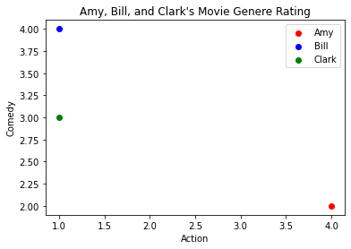

```python
plt.scatter(df.loc['Amy', 'Action'], df.loc['Amy', 'Comedy'], color='Red', label='Amy')
plt.scatter(df.loc['Bill', 'Action'], df.loc['Bill', 'Comedy'], color='Blue', label='Bill')
plt.scatter(df.loc['Clark', 'Action'], df.loc['Clark', 'Comedy'], color='Green', label='Clark')
plt.legend()
plt.title("Amy, Bill, and Clark's Movie Genere Rating")
plt.xlabel('Action')
plt.ylabel('Comedy')
```

# Euclidean distance

```python
def euclidean_distance(vector1, vector2):
    return np.sqrt(np.sum((vector1 - vector2) ** 2))

def euclidean_distance(vector1, vector2):
    return np.linalg.norm(vector1 - vector2)

from scipy.spatial.distance import euclidean
```

```python
print("Distance between Amy and Clark:", euclidean(df.loc['Amy'], df.loc['Clark']))
print("Distance bewteen Bill and Clark:", euclidean(df.loc['Bill'], df.loc['Clark']))
```

```
Distance between Amy and Clark: 3.1622776601683795
Distance bewteen Bill and Clark: 1.0
```

# Cosine distance or similarity

```python
def cosine_similarity(vector1, vector2):
    return np.dot(vector1, vector2) / (np.sqrt(np.dot(vector1, vector1)) * np.sqrt(np.dot(vector2, vector2)))

from scipy.spatial.distance import cosine
```

```python
print("Cosine between Amy and Clark:", cosine(df.loc['Amy'], df.loc['Clark']), "\n",
      "Cosine between Bill and Clark:", cosine(df.loc['Bill'], df.loc['Clark']))
```

```
Cosine between Amy and Clark: 0.29289321881345254
 Cosine between Bill and Clark: 0.002945514498418511
```

```python
ratings = np.array([[4, 2, 5, 4, 3],
                    [1, 4, 3, 5, 2],
                    [1, 3, 2, 3, 1]])
df = pd.DataFrame(ratings, columns = ['Action', 'Comedy', 'Romance', 'Sci-Fi', 'Drama'], index = ['Amy', 'Bill', 'Clark'])
df
```

|  | Action | Comedy | Romance | Sci-Fi | Drama |
| --- | --- | --- | --- | --- | --- |
| Amy | 4 | 2 | 5 | 4 | 3 |
| Bill | 1 | 4 | 3 | 5 | 2 |
| Clark | 1 | 3 | 2 | 3 | 1 |

```python
# Calculate the Euclidian distance between Amy and Clarke and Bill and Clark with more dimentional data
print("Distance between Amy and Clark:", euclidean(df.loc['Amy'], df.loc['Clark']))
print("Distance bewteen Bill to Clark:", euclidean(df.loc['Bill'], df.loc['Clark']))
```

```
Distance between Amy and Clark: 4.898979485566356
Distance bewteen Bill to Clark: 2.6457513110645907
```

```python
# Calculate the cosine simularity distance between Amy and Clarke and Bill and Clark with more dimentional data
print("Cosine between Amy and Clark:", cosine(df.loc['Amy'], df.loc['Clark']))
print("Cosine between Bill and Clark:", cosine(df.loc['Bill'], df.loc['Clark']))
```

```
Cosine between Amy and Clark: 0.1460874361700335
Cosine between Bill and Clark: 0.009132611386275413
```

# Pearson correlation

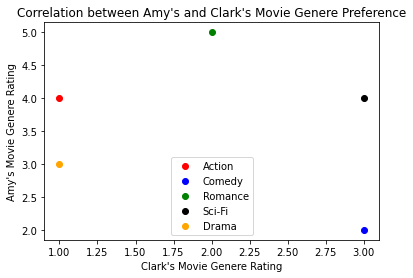

```python
# Plot Amy's genere rating vs Clark's genere rating
plt.scatter(df.loc['Clark','Action'], df.loc['Amy','Action'], color='Red', label='Action')
plt.scatter(df.loc['Clark','Comedy'], df.loc['Amy','Comedy'], color='Blue', label='Comedy')
plt.scatter(df.loc['Clark','Romance'], df.loc['Amy','Romance'], color='Green', label='Romance')
plt.scatter(df.loc['Clark','Sci-Fi'], df.loc['Amy','Sci-Fi'], color='Black', label='Sci-Fi')
plt.scatter(df.loc['Clark','Drama'], df.loc['Amy','Drama'], color='Orange', label='Drama')
plt.legend()
plt.title("Correlation between Amy's and Clark's Movie Genere Preference")
plt.xlabel("Clark's Movie Genere Rating")
plt.ylabel("Amy's Movie Genere Rating")
plt.show()
```

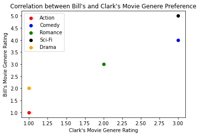

```python
# Plot Bill's genere rating vs Clark's genere rating
plt.scatter(df.loc['Clark', 'Action'], df.loc['Bill', 'Action'], color='Red', label='Action')
plt.scatter(df.loc['Clark', 'Comedy'], df.loc['Bill', 'Comedy'], color='Blue', label='Comedy')
plt.scatter(df.loc['Clark', 'Romance'], df.loc['Bill', 'Romance'], color='Green', label='Romance')
plt.scatter(df.loc['Clark', 'Sci-Fi'], df.loc['Bill', 'Sci-Fi'], color='Black', label='Sci-Fi')
plt.scatter(df.loc['Clark', 'Drama'], df.loc['Bill', 'Drama'], color='Orange', label='Drama')
plt.legend()
plt.title("Correlation between Bill's and Clark's Movie Genere Preference")
plt.xlabel("Clark's Movie Genere Rating")
plt.ylabel("Bill's Movie Genere Rating")
plt.show()
```

```python
from scipy.stats.stats import pearsonr
```

```python
print("Pearson's Coefficient between Amy and Clark:", pearsonr(df.loc['Amy'], df.loc['Clark'])[0], "\n",
      "Pearson's Coefficient between Bill and Clark:", pearsonr(df.loc['Bill'], df.loc['Clark'])[0])
```

```
Pearson's Coefficient between Amy and Clark: -0.2192645048267573
 Pearson's Coefficient between Bill and Clark: 0.9486832980505138
```

# Creating simple recommender systems

```python
ratings = pd.read_csv('ratings.csv')
movies = pd.read_csv('movies.csv')
```

```python
movies.head()
```

|  | movieId | title | genres |
| --- | --- | --- | --- |
| 0 | 1 | Toy Story (1995) | Adventure\|Animation\|Children\|Comedy\|Fantasy |
| 1 | 2 | Jumanji (1995) | Adventure\|Children\|Fantasy |
| 2 | 3 | Grumpier Old Men (1995) | Comedy\|Romance |
| 3 | 4 | Waiting to Exhale (1995) | Comedy\|Drama\|Romance |
| 4 | 5 | Father of the Bride Part II (1995) | Comedy |

```python
ratings.head()
```

|  | userId | movieId | rating | timestamp |
| --- | --- | --- | --- | --- |
| 0 | 1 | 1 | 4.0 | 964982703 |
| 1 | 1 | 3 | 4.0 | 964981247 |
| 2 | 1 | 6 | 4.0 | 964982224 |
| 3 | 1 | 47 | 5.0 | 964983815 |
| 4 | 1 | 50 | 5.0 | 964982931 |

```python
pd.to_datetime(ratings['timestamp'], unit='s')
```

```
0        2000-07-30 18:45:03
1        2000-07-30 18:20:47
2        2000-07-30 18:37:04
3        2000-07-30 19:03:35
4        2000-07-30 18:48:51
                 ...
100831   2017-05-03 21:53:22
100832   2017-05-03 22:21:31
100833   2017-05-08 19:50:47
100834   2017-05-03 21:19:12
100835   2017-05-03 21:20:15
Name: timestamp, Length: 100836, dtype: datetime64[ns]
```

```python
ratings.groupby('movieId').sum()
```

| movieId | userId | rating | timestamp |
| --- | --- | --- | --- |
| 1 | 65904 | 843.0 | 242914455479 |
| 2 | 36251 | 377.5 | 124938583322 |
| 3 | 14747 | 169.5 | 52265734386 |
| 4 | 1539 | 16.5 | 6290052048 |
| 5 | 14679 | 150.5 | 48640552594 |
| ... | ... | ... | ... |
| 193581 | 184 | 4.0 | 1537109082 |
| 193583 | 184 | 3.5 | 1537109545 |
| 193585 | 184 | 3.5 | 1537109805 |
| 193587 | 184 | 3.5 | 1537110021 |
| 193609 | 331 | 4.0 | 1537157606 |

9724 rows × 3 columns

```python
ratings.groupby('movieId').sum().sort_values(by='rating', ascending=False)
```

| movieId | userId | rating | timestamp |
| --- | --- | --- | --- |
| 318 | 95829 | 1404.0 | 376924839127 |
| 356 | 101385 | 1370.0 | 386165236681 |
| 296 | 90621 | 1288.5 | 349204311001 |
| 2571 | 85236 | 1165.5 | 350270041779 |
| 593 | 85535 | 1161.0 | 320035674330 |
| ... | ... | ... | ... |
| 160872 | 21 | 0.5 | 1468113939 |
| 8236 | 580 | 0.5 | 1167791433 |
| 57326 | 232 | 0.5 | 1241823595 |
| 82684 | 567 | 0.5 | 1525289916 |
| 138798 | 298 | 0.5 | 1450453125 |

9724 rows × 3 columns

```python
movies.set_index('movieId', inplace=True)
```

```python
top_idx = ratings.groupby('movieId').sum().sort_values(by='rating', ascending=False).index
movies.loc[top_idx]
```

| movieId | title | genres |
| --- | --- | --- |
| 318 | Shawshank Redemption, The (1994) | Crime\|Drama |
| 356 | Forrest Gump (1994) | Comedy\|Drama\|Romance\|War |
| 296 | Pulp Fiction (1994) | Comedy\|Crime\|Drama\|Thriller |
| 2571 | Matrix, The (1999) | Action\|Sci-Fi\|Thriller |
| 593 | Silence of the Lambs, The (1991) | Crime\|Horror\|Thriller |
| ... | ... | ... |
| 160872 | Satanic (2016) | Horror |
| 8236 | While the City Sleeps (1956) | Drama\|Film-Noir |
| 57326 | In the Name of the King: A Dungeon Siege Tale ... | Action\|Adventure\|Fantasy |
| 82684 | Trash Humpers (2009) | Drama |
| 138798 | Joe Dirt 2: Beautiful Loser (2015) | Comedy |

9724 rows × 2 columns

```python
top_idx = ratings.groupby('movieId').sum().sort_values(by='rating', ascending=False).index
movies.loc[top_idx]
```

| movieId | title | genres |
| --- | --- | --- |
| 318 | Shawshank Redemption, The (1994) | Crime\|Drama |
| 356 | Forrest Gump (1994) | Comedy\|Drama\|Romance\|War |
| 296 | Pulp Fiction (1994) | Comedy\|Crime\|Drama\|Thriller |
| 2571 | Matrix, The (1999) | Action\|Sci-Fi\|Thriller |
| 593 | Silence of the Lambs, The (1991) | Crime\|Horror\|Thriller |
| ... | ... | ... |
| 160872 | Satanic (2016) | Horror |
| 8236 | While the City Sleeps (1956) | Drama\|Film-Noir |
| 57326 | In the Name of the King: A Dungeon Siege Tale ... | Action\|Adventure\|Fantasy |
| 82684 | Trash Humpers (2009) | Drama |
| 138798 | Joe Dirt 2: Beautiful Loser (2015) | Comedy |

9724 rows × 2 columns

# Creating a simple collaborative filtering recommender

```python
wide = ratings.pivot(index='userId', columns='movieId', values='rating')
wide.head()
```

| movieId userId | 1 | 2 | 3 | 4 | 5 | 6 | 7 | 8 | 9 | 10 | ... | 193565 | 193567 | 193571 | 193573 | 193579 | 193581 | 193583 | 193585 | 193587 | 193609 |
| --- | --- | --- | --- | --- | --- | --- | --- | --- | --- | --- | --- | --- | --- | --- | --- | --- | --- | --- | --- | --- | --- |
| 1 | 4.0 | NaN | 4.0 | NaN | NaN | 4.0 | NaN | NaN | NaN | NaN | ... | NaN | NaN | NaN | NaN | NaN | NaN | NaN | NaN | NaN | NaN |
| 2 | NaN | NaN | NaN | NaN | NaN | NaN | NaN | NaN | NaN | NaN | ... | NaN | NaN | NaN | NaN | NaN | NaN | NaN | NaN | NaN | NaN |
| 3 | NaN | NaN | NaN | NaN | NaN | NaN | NaN | NaN | NaN | NaN | ... | NaN | NaN | NaN | NaN | NaN | NaN | NaN | NaN | NaN | NaN |
| 4 | NaN | NaN | NaN | NaN | NaN | NaN | NaN | NaN | NaN | NaN | ... | NaN | NaN | NaN | NaN | NaN | NaN | NaN | NaN | NaN | NaN |
| 5 | 4.0 | NaN | NaN | NaN | NaN | NaN | NaN | NaN | NaN | NaN | ... | NaN | NaN | NaN | NaN | NaN | NaN | NaN | NaN | NaN | NaN |

5 rows × 9724 columns

```python
cor = wide.T.corr()
```

```python
cor.head()
```

| userId | 1 | 2 | 3 | 4 | 5 | 6 | 7 | 8 | 9 | 10 | ... | 601 | 602 | 603 | 604 | 605 | 606 | 607 | 608 | 609 | 610 |
| --- | --- | --- | --- | --- | --- | --- | --- | --- | --- | --- | --- | --- | --- | --- | --- | --- | --- | --- | --- | --- | --- |
| 1 | 1.000000 | NaN | 0.079819 | 0.207983 | 0.268749 | -0.291636 | -0.118773 | 0.469668 | 0.918559 | -0.037987 | ... | 9.157371e-02 | -1.597727e-16 | -0.061503 | -0.407556 | -0.164871 | 0.066378 | 0.174557 | 0.268070 | -0.175412 | -0.032086 |
| 2 | NaN | 1.0 | NaN | NaN | NaN | NaN | -0.991241 | NaN | NaN | 0.037796 | ... | -3.873468e-01 | NaN | -1.000000 | NaN | NaN | 0.583333 | NaN | -0.125000 | NaN | 0.623288 |
| 3 | 0.079819 | NaN | 1.000000 | NaN | NaN | NaN | NaN | NaN | NaN | NaN | ... | NaN | NaN | 0.433200 | NaN | NaN | -0.791334 | -0.333333 | -0.395092 | NaN | 0.569562 |
| 4 | 0.207983 | NaN | NaN | 1.000000 | -0.336525 | 0.148498 | 0.542861 | 0.117851 | NaN | 0.485794 | ... | -2.221127e-01 | 3.966413e-01 | 0.090090 | -0.080296 | 0.400124 | 0.144603 | 0.116518 | -0.170501 | -0.277350 | -0.043786 |
| 5 | 0.268749 | NaN | NaN | -0.336525 | 1.000000 | 0.043166 | 0.158114 | 0.028347 | NaN | -0.777714 | ... | 2.719480e-16 | 1.533034e-01 | 0.234743 | 0.067791 | -0.364156 | 0.244321 | 0.231080 | -0.020546 | 0.384111 | 0.040582 |

5 rows × 610 columns

```python
cor.loc[2].sort_values(ascending=False)
```

```
userId
2      1.0
341    1.0
93     1.0
143    1.0
148    1.0
      ...
602    NaN
604    NaN
605    NaN
607    NaN
609    NaN
Name: 2, Length: 610, dtype: float64
```

```python
wide.loc[2].notna().equals(wide.loc[341].notna())
```

```
False
```

```python
rated_5_by_341_not_watched_by_2 = (wide.loc[341] == 5) & (wide.loc[2].isna())
print(wide.loc[2][rated_5_by_341_not_watched_by_2])
print(wide.loc[341][rated_5_by_341_not_watched_by_2])
```

```
movieId
1       NaN
59900   NaN
Name: 2, dtype: float64
movieId
1        5.0
59900    5.0
Name: 341, dtype: float64
```

```python
wide.fillna(-1, inplace=True)
```

```python
euclidean(wide.iloc[2], wide.iloc[341])
```

```
41.212862069989754
```

```python
from scipy.spatial.distance import pdist, squareform
```

```python
euclidean_distances = squareform(pdist(wide, metric=euclidean)) # or metric='euclidean'
```

```python
euclidean_df = pd.DataFrame(data=euclidean_distances, columns=wide.index, index=wide.index)
```

```python
euclidean_df.head()
```

| userId | 1 | 2 | 3 | 4 | 5 | 6 | 7 | 8 | 9 | 10 | ... | 601 | 602 | 603 | 604 | 605 | 606 | 607 | 608 | 609 | 610 |
| --- | --- | --- | --- | --- | --- | --- | --- | --- | --- | --- | --- | --- | --- | --- | --- | --- | --- | --- | --- | --- | --- |
| 1 | 0.000000 | 86.239492 | 84.731930 | 96.979379 | 84.516271 | 108.083301 | 91.651514 | 84.380092 | 86.203248 | 96.969067 | ... | 95.430603 | 90.288427 | 147.939177 | 91.350972 | 96.224997 | 165.230143 | 90.862534 | 126.232920 | 84.279298 | 179.904836 |
| 2 | 86.239492 | 0.000000 | 36.806929 | 74.567084 | 41.039615 | 84.777650 | 60.172668 | 41.318882 | 40.450587 | 57.295288 | ... | 55.859198 | 58.423026 | 145.090489 | 52.822817 | 69.235107 | 158.923724 | 71.674612 | 124.893955 | 37.016888 | 171.373860 |
| 3 | 84.731930 | 36.806929 | 0.000000 | 73.908727 | 39.956226 | 84.584277 | 60.112395 | 40.441316 | 39.172695 | 58.150666 | ... | 59.895743 | 57.701820 | 144.296570 | 51.850747 | 68.233057 | 158.848985 | 70.664701 | 124.946989 | 36.173194 | 172.971819 |
| 4 | 96.979379 | 74.567084 | 73.908727 | 0.000000 | 72.608539 | 101.847926 | 83.330667 | 74.639132 | 75.591005 | 85.743804 | ... | 84.604964 | 81.455509 | 137.952891 | 81.018516 | 90.461318 | 158.726179 | 89.693924 | 131.524713 | 73.593478 | 178.462181 |
| 5 | 84.516271 | 41.039615 | 39.956226 | 72.608539 | 0.000000 | 77.479029 | 59.958319 | 33.837849 | 43.543082 | 60.274373 | ... | 61.253571 | 48.383882 | 142.762040 | 47.833043 | 66.740168 | 157.171880 | 69.188149 | 122.697799 | 35.270384 | 172.935682 |

5 rows × 610 columns

```python
euclidean_df.loc[2].sort_values()
```

```
userId
2        0.000000
442     29.000000
461     30.495901
189     30.809901
508     31.488093
          ...
448    171.200175
610    171.373860
599    185.184368
474    206.630709
414    232.408046
Name: 2, Length: 610, dtype: float64
```

```python
euclidean_df.loc[2].sort_values().loc[341]
```

```
42.91852746774987
```

```python
cosine_distances = squareform(pdist(wide, metric='cosine'))
cosine_df = pd.DataFrame(cosine_distances, columns=wide.index, index=wide.index)
cosine_df.loc[2].sort_values()
```

```
userId
2      0.000000
442    0.042025
461    0.046059
189    0.046957
508    0.049443
         ...
610    0.762312
448    0.817785
599    0.936812
474    0.975777
414    1.084648
Name: 2, Length: 610, dtype: float64
```

```python
cosine_df.loc[2].sort_values().loc[341]
```

```
0.0892952689103661
```